# chap3.13

hyojunahn

2017년 10월 9일

# 3.13

### (a) Using the rnorm() function, create a vector, x, containing 100 observations drawn from a N(0, 1) distribution. This represents a feature, X.

```r
set.seed(123)
a <- rnorm(100)
a
```

```
##   [1] -0.560475647 -0.230177489  1.558708314  0.070508391  0.129287735
##   [6]  1.715064987  0.460916206 -1.265061235 -0.686852852 -0.445661970
##  [11]  1.224081797  0.359813827  0.400771451  0.110682716 -0.555841135
##  [16]  1.786913137  0.497850478 -1.966617157  0.701355902 -0.472791408
##  [21] -1.067823706 -0.217974915 -1.026004448 -0.728891229 -0.625039268
##  [26] -1.686693311  0.837787044  0.153373118 -1.138136937  1.253814921
##  [31]  0.426464221 -0.295071483  0.895125661  0.878133488  0.821581082
##  [36]  0.688640254  0.553917654 -0.061911711 -0.305962664 -0.380471001
##  [41] -0.694706979 -0.207917278 -1.265396352  2.168955965  1.207961998
##  [46] -1.123108583 -0.402884835 -0.466655354  0.779965118 -0.083369066
##  [51]  0.253318514 -0.028546755 -0.042870457  1.368602284 -0.225770986
##  [56]  1.516470604 -1.548752804  0.584613750  0.123854244  0.215941569
##  [61]  0.379639483 -0.502323453 -0.333207384 -1.018575383 -1.071791226
##  [66]  0.303528641  0.448209779  0.053004227  0.922267468  2.050084686
##  [71] -0.491031166 -2.309168876  1.005738524 -0.709200763 -0.688008616
##  [76]  1.025571370 -0.284773007 -1.220717712  0.181303480 -0.138891362
##  [81]  0.005764186  0.385280401 -0.370660032  0.644376549 -0.220486562
##  [86]  0.331781964  1.096839013  0.435181491 -0.325931586  1.148807618
##  [91]  0.993503856  0.548396960  0.238731735 -0.627906076  1.360652449
##  [96] -0.600259587  2.187332993  1.532610626 -0.235700359 -1.026420900
```

.

.

- rnorm(n, mean = 0, sd = 1)
- If mean or sd are not specified they assume the default values of 0 and 1, respectively.

### (b) Using the rnorm() function, create a vector, eps, containing 100 observations drawn from a N(0, 0.25) distribution i.e. a normal distribution with mean zero and variance 0.25.

```r
b <- rnorm(100, mean = 0, sd = 0.25^0.5)
b
```

```
##   [1] -0.35520328  0.12844185 -0.12334594 -0.17377130 -0.47580928
##   [6] -0.02251386 -0.39245223 -0.83397097 -0.19011326  0.45949830
##  [11] -0.28767348  0.30398216 -0.80894135 -0.02778098  0.25970360
##  [16]  0.15057668  0.05283810 -0.32035300 -0.42485217 -0.51206440
##  [21]  0.05882330 -0.47373731 -0.24527872 -0.12804610  0.92193100
##  [26] -0.32597495  0.11769329  0.03898042 -0.48092832 -0.03565404
##  [31]  0.72227543  0.22575203  0.02061646 -0.21124842 -1.02662361
##  [36]  0.56566861 -0.73032004  0.36997376  0.95455178 -0.72194658
##  [41]  0.35089217 -0.13109874 -0.78607208 -0.75733383 -0.80076809
##  [46] -0.26545326 -0.73087779  0.34395839  1.05005447 -0.64351524
##  [51]  0.39386942  0.38452112  0.16610129 -0.50418830 -0.05972630
##  [56] -0.14019767  0.28149477 -0.18621938  0.48848669 -0.18729043
##  [61]  0.52635573 -0.52458850 -0.63007762  1.62051997 -0.20842879
##  [66]  0.14911380  0.31828484 -0.24189031  0.25843102  0.18448226
##  [71] -0.10769025  0.03264652 -0.01703363  1.06422595 -0.37066805
##  [76] -0.54799813  0.01889420  0.15524037  0.21826174 -0.22918267
##  [81] -0.53166307  0.63159259 -0.17482519 -0.43275643 -0.11813978
##  [86] -0.09858795  0.55496014  0.04236865  0.37702689 -0.24964601
##  [91]  0.10722265 -0.16234296  0.04729176 -0.44768168 -0.65540077
##  [96]  0.99860669  0.30035441 -0.62563568 -0.30558296 -0.59274004
```

```r
c <- -1 + 0.5*a + b
c
```

```
##   [1] -1.63544111 -0.98664689 -0.34399178 -1.13851710 -1.41116542
##   [6] -0.16498137 -1.16199413 -2.46650159 -1.53353969 -0.76333268
##  [11] -0.67563258 -0.51611093 -1.60855563 -0.97243962 -1.01821697
##  [16]  0.04403325 -0.69823666 -2.30366158 -1.07417422 -1.74846010
##  [21] -1.47508855 -1.58272476 -1.75828095 -1.49249171 -0.39058863
##  [26] -2.16932161 -0.46341319 -0.88433302 -2.04999679 -0.40874658
##  [31] -0.06449246 -0.92178371 -0.53182071 -0.77218167 -1.61583307
##  [36] -0.09001127 -1.45336121 -0.66098210 -0.19842955 -1.91218208
##  [41] -0.99646132 -1.23505738 -2.41877026 -0.67285584 -1.19678709
##  [46] -1.82700755 -1.93232021 -0.88936929  0.44003703 -1.68519977
##  [51] -0.47947132 -0.62975226 -0.85533394 -0.81988716 -1.17261180
##  [56] -0.38196237 -1.49288164 -0.89391250 -0.44958618 -1.07931964
##  [61] -0.28382453 -1.77575023 -1.79668131  0.11123228 -1.74432441
##  [66] -0.69912188 -0.45761027 -1.21538820 -0.28043524  0.20952461
##  [71] -1.35320584 -2.12193792 -0.51416436 -0.29037443 -1.71467236
##  [76] -1.03521245 -1.12349230 -1.45511848 -0.69108652 -1.29862835
##  [81] -1.52878097 -0.17576721 -1.36015521 -1.11056816 -1.22838307
##  [86] -0.93269697  0.10337965 -0.74004061 -0.78593890 -0.67524220
##  [91] -0.39602542 -0.88814448 -0.83334237 -1.76163472 -0.97507454
##  [96] -0.30152310  0.39402091 -0.85933037 -1.42343314 -2.10595049
```

```r
length(c)
```

```
## [1] 100
```

.

.

y의 길이는 100이다. β0 와 β1은 -1과 0.5이다.

### (d) Create a scatterplot displaying the relationship between x and y. Comment on what you observe.

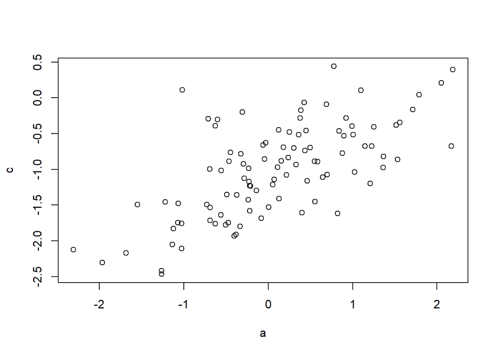

```r
plot(a,c)
```

. .

.

- It looks like a linear relationship. and + direction.

### (e) Fit a least squares linear model to predict y using x. Comment on the model obtained. How do ˆ β0 and ˆ β1 compare to β0 and β1?

```r
lm.fit <- lm(c~a)
summary(lm(c~a))
```

```
##
## Call:
## lm(formula = c ~ a)
##
## Residuals:
##      Min       1Q   Median       3Q      Max
## -0.95367 -0.34175 -0.04375  0.29032  1.64520
##
## Coefficients:
##             Estimate Std. Error t value Pr(>|t|)
## (Intercept) -1.05140    0.04878 -21.556  < 2e-16 ***
## a            0.47376    0.05344   8.865  3.5e-14 ***
## ---
## Signif. codes:  0 '***' 0.001 '**' 0.01 '*' 0.05 '.' 0.1 ' ' 1
##
## Residual standard error: 0.4854 on 98 degrees of freedom
## Multiple R-squared:  0.4451, Adjusted R-squared:  0.4394
## F-statistic:  78.6 on 1 and 98 DF,  p-value: 3.497e-14
```

### (f) Display the least squares line on the scatterplot obtained in (d). Draw the population regression line on the plot, in a different color. Use the legend() command to create an appropriate legend.

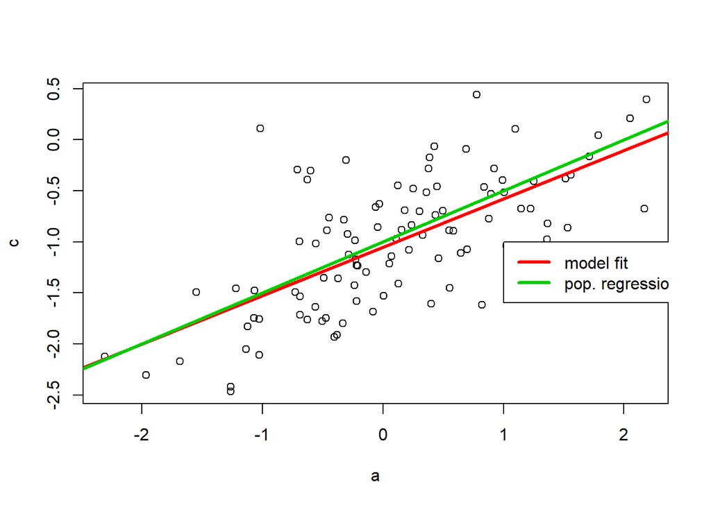

```r
plot(a,c)
abline(lm.fit, lwd=3, col=2)
abline(-1,0.5,lwd=3,col=3)
legend(-1, legend = c("model fit", "pop. regression"), col=2:3, lwd=3)
```

### (g) Now fit a polynomial regression model that predicts y using x and x2. Is there evidence that the quadratic term improves the model fit? Explain your answer.

```r
lm.fit_sq = lm(c~a+I(a^2))
summary(lm.fit_sq)
```

```
##
## Call:
## lm(formula = c ~ a + I(a^2))
##
## Residuals:
##      Min       1Q   Median       3Q      Max
## -0.96841 -0.36457 -0.05954  0.32720  1.66598
##
## Coefficients:
##             Estimate Std. Error t value Pr(>|t|)
## (Intercept) -1.01520    0.06017 -16.873  < 2e-16 ***
## a            0.48428    0.05440   8.903 3.13e-14 ***
## I(a^2)      -0.04460    0.04342  -1.027    0.307
## ---
## Signif. codes:  0 '***' 0.001 '**' 0.01 '*' 0.05 '.' 0.1 ' ' 1
##
## Residual standard error: 0.4852 on 97 degrees of freedom
## Multiple R-squared:  0.451,  Adjusted R-squared:  0.4397
## F-statistic: 39.85 on 2 and 97 DF,  p-value: 2.333e-13
```

- a^2의 값이 유효하지 않다. 모델에 적용하는데 적절치 않다고 생각한다.

### (h) Repeat (a)–(f) after modifying the data generation process in such a way that there is less noise in the data. The model (3.39) should remain the same. You can do this by decreasing the variance of the normal distribution used to generate the error term in (b). Describe your results.

```r
eps2 <- rnorm(100, sd=0.1)  # prior sd was 0.5
y2 <- -1 + 0.5*a + eps2
fit.lm2 <- lm(y2 ~ a)
summary(fit.lm2)
```

```
##
## Call:
## lm(formula = y2 ~ a)
##
## Residuals:
##      Min       1Q   Median       3Q      Max
## -0.18820 -0.06696 -0.01450  0.06054  0.20528
##
## Coefficients:
##              Estimate Std. Error t value Pr(>|t|)
## (Intercept) -0.986738   0.009514 -103.72   <2e-16 ***
## a            0.486558   0.010424   46.68   <2e-16 ***
## ---
## Signif. codes:  0 '***' 0.001 '**' 0.01 '*' 0.05 '.' 0.1 ' ' 1
##
## Residual standard error: 0.09467 on 98 degrees of freedom
## Multiple R-squared:  0.957,  Adjusted R-squared:  0.9565
## F-statistic:  2179 on 1 and 98 DF,  p-value: < 2.2e-16
```

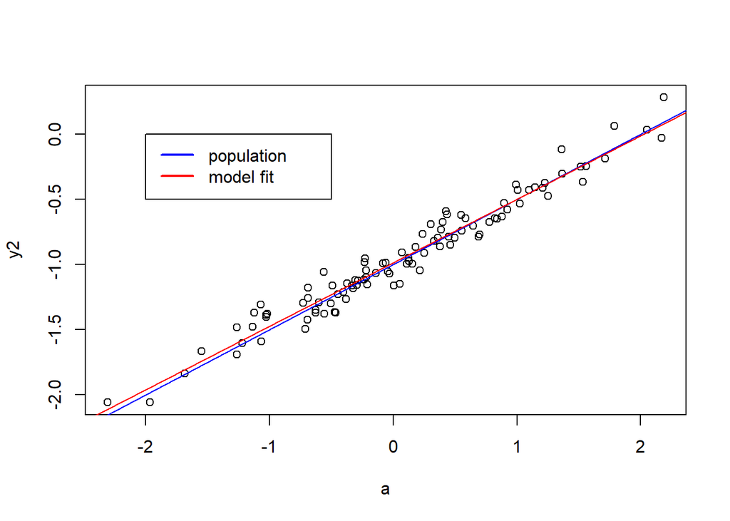

```r
plot(a, y2)
abline(-1, 0.5, col="blue")   # true regression
abline(fit.lm2, col="red")    # fitted regression
legend(x = c(-2,-0.5),
       y = c(-0.5,0),
       legend = c("population", "model fit"),
       col = c("blue","red"), lwd=2 )
```

### (i) Repeat (a)–(f) after modifying the data generation process in such a way that there is more noise in the data. The model(3.39) should remain the same. You can do this by increasing the variance of the normal distribution used to generate the error term in (b). Describe your results.

```r
eps3 <- rnorm(100, sd=1)  # orig sd was 0.5
y3 <- -1 + 0.5*a + eps3
fit.lm3 <- lm(y3 ~ a)
summary(fit.lm3)
```

```
##
## Call:
## lm(formula = y3 ~ a)
##
## Residuals:
##      Min       1Q   Median       3Q      Max
## -2.42800 -0.66168  0.05341  0.70315  2.61398
##
## Coefficients:
##             Estimate Std. Error t value Pr(>|t|)
## (Intercept)  -1.0317     0.1048  -9.842 2.66e-16 ***
## a             0.4498     0.1148   3.917 0.000166 ***
## ---
## Signif. codes:  0 '***' 0.001 '**' 0.01 '*' 0.05 '.' 0.1 ' ' 1
##
## Residual standard error: 1.043 on 98 degrees of freedom
## Multiple R-squared:  0.1354, Adjusted R-squared:  0.1265
## F-statistic: 15.34 on 1 and 98 DF,  p-value: 0.0001659
```

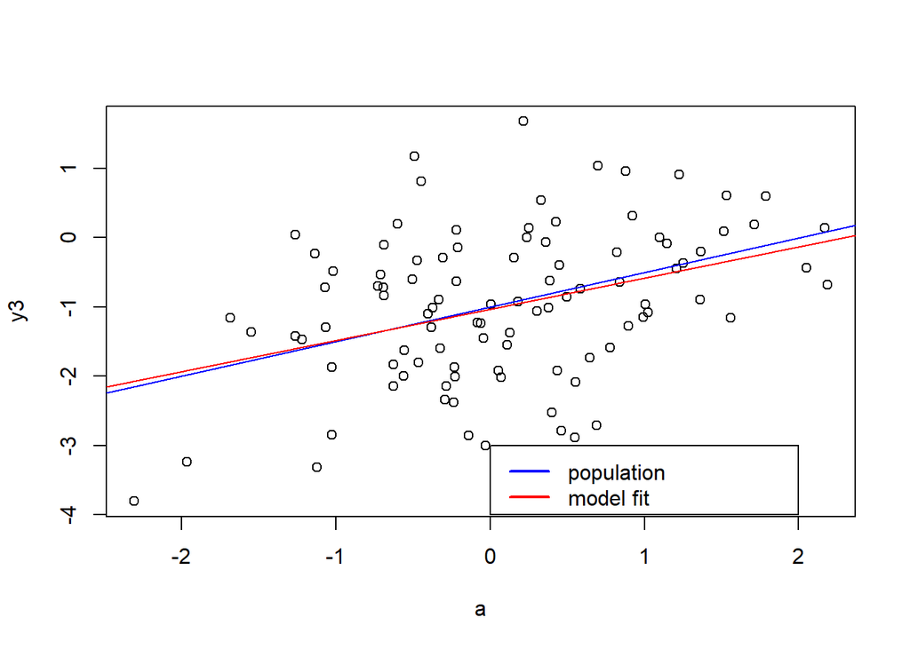

```r
plot(a, y3)
abline(-1, 0.5, col="blue")   # true regression
abline(fit.lm3, col="red")    # fitted regression
legend(x = c(0,2),
       y = c(-4,-3),
       legend = c("population", "model fit"),
       col = c("blue","red"), lwd=2 )
```

### (j) What are the confidence intervals for β0 and β1 based on the original data set, the noisier data set, and the less noisy data set? Comment on your results.

```r
confint(lm.fit)
```

```
##                  2.5 %     97.5 %
## (Intercept) -1.1481951 -0.9546080
## a            0.3677156  0.5798128
```

```r
confint(fit.lm2)
```

```
##                  2.5 %     97.5 %
## (Intercept) -1.0056183 -0.9678582
## a            0.4658726  0.5072432
```

```r
confint(fit.lm3)
```

```
##                  2.5 %     97.5 %
## (Intercept) -1.2397014 -0.8236746
## a            0.2219355  0.6777410
```